# first_val_app

```python
%reload_ext autoreload
%autoreload 2

import pandas as pd
import numpy as np
from IPython.core.display import HTML, Javascript

from mylibs.configs import (
    capp_config,
    waterfall_config,
    scoreband_config,
    factor_config,
    PSI_threshold,
    AHI_threshold,
    CA_threshold,
    backend_test_thresholds,
)
from mylibs.table_display import (
    readModelInfo,
    formatMultiIndexTable,
    docTable,
    create_and_excecute_code_cell,
    getWaterfallTable,
    getFrontendPSI,
    computeFactorCA,
    computeMultiFactorCA,
    getStyledTable,
)

from mylibs.backend_tests import (
    calcAR,
    calcRiskRankingTable,
    getRiskRankingOutcome,
    getRiskRankingChart,
    calcSubsegmentRanking,
    calcMultiFactorAR,
    calcFactorAR,
)


MODEL_INFO_FILE = './data/validation_info.xlsx'

MODEL_INFO_ModelInfo = readModelInfo(MODEL_INFO_FILE,'Model-Info')
MODEL_INFO_DocInfo = readModelInfo(MODEL_INFO_FILE,'Doc-Info')
MODEL_INFO_DocSignoff = readModelInfo(MODEL_INFO_FILE,'Doc-Signoff')
MODEL_INFO_DataSource = readModelInfo(MODEL_INFO_FILE,'Data-Source')
MODEL_INFO_DataPeriod = readModelInfo(MODEL_INFO_FILE,'Data-Period')
MODEL_INFO_KeyDefinitions = readModelInfo(MODEL_INFO_FILE,'Key-Definitions')
MODEL_INFO_Chrono = readModelInfo(MODEL_INFO_FILE,'Chrono')
MODEL_INFO_OviewOS = readModelInfo(MODEL_INFO_FILE,'Port-Overview-OS')
MODEL_INFO_OviewCnt = readModelInfo(MODEL_INFO_FILE,'Port-Overview-Cnt')

strDocname = MODEL_INFO_DocInfo[MODEL_INFO_DocInfo['Field'] == 'Name']['Value'].values[0]
strFilename = MODEL_INFO_DocInfo[MODEL_INFO_DocInfo['Field'] == 'Filename']['Value'].values[0]
strPortfolio = MODEL_INFO_ModelInfo[MODEL_INFO_ModelInfo['Field'] == 'Portfolio Name']['Value'].values[0]
strModelname = MODEL_INFO_ModelInfo[MODEL_INFO_ModelInfo['Field'] == 'Model Name']['Value'].values[0]

dfData = pd.read_csv('./data/ascore_val_data.csv', dtype={'cohort': str})

# load custom css styling
def css_styling():
    styles = open("./css/c-app.css", "r").read()
    return HTML('<style>' + styles + '</style>' +
                f'<header style="visibility: hidden;">{strDocname}</header>'
               )
css_styling()
```

Model Validation Report 2022

Consumer Unsecured Lending

Application Scorecard

| Field | Value |
| --- | --- |
| Portfolio Name | Consumer Unsecured Lending |
| Model Name | Application Scorecard |
| Model Version | CUAS10 |
| Model Owner | Modelling Department |
| Model Developer | Model Consultancy Ltd |
| Model Last Validation Date | Mar 2021 |

Model Validation Report 2022  
Consumer Unsecured Lending - Application Scorecard

**Confidentiality**  
This document contains proprietary information that is confidential to our company. Disclosure of this document in full or part may result in material damage to the company. Written permission must be obtained from our company prior to the disclosure of this document to a third party.

| Field | Value |
| --- | --- |
| Name | Model Validation Report 2022 |
| Date | Mar 2022 |
| Status | Draft |
| Filename | Consumer Unsecured Lending - Ascore Validation 2022 |
| Author | Nguyen Van XXX |
| Confidentiality | Internal Use |

**Document Sign-off**

| Role | Title | Name | Signature |
| --- | --- | --- | --- |
| Author | Analyst | Nguyen Van XXX |  |
| Reviewer | Senior Analyst | Tran Van Zelenski |  |
| Approver | Head, Validation | Le Van Putin |  |

# Introduction

```python
import pandas as pd
dfBscore_sumry = pd.read_csv('./data/bscore_score_cohort.csv')
```

## Background

To have a better tool to assess customer credit risk, the bank had develop the a model suite for Consumer Unsecured Lending segment. It comprised of an application scorecard, a behaviour scorecard and PD/EAD/LGD segmentation models.  
The application scorecard was developed in 2014 and implemented in Oct 2015, after gone through independent validation processes and obtained the approval for uses by Credit Risk Committee. Since then the scorecard was being assessed annually and concluding to be fit for continued uses.  
The newly developed scorecards and segmentation models had achieved excellent risk ranking power, with AR of 71% for the Ascore, 85% for Bscore and 80% for PD models.

## Scope of Validation

The scope of this review is to analyse the performance of the application scorecard for Consumer Unsecured Lending portfolios. Data was based on recent cohorts and asss if the scorecard is fit for continue uses. This report is to document the validation results and findings.

The performance of the scorecard is assessed against stardards set out in our Independent Validation Guidelines. These take into account the regulatory requirements. We employed the following color coding scheme in our assessment of the scorecard.

Outcome Color Code

| Color | Outcome |
| --- | --- |
| Green | Indicates generally complied with requirements/standards |
| Yellow | Indicates moderate gaps to requirements/standards |
| Red | Indicates significant gaps to requirements/standards |

# Executive Summary

# Portfolio Overview

The Consumer Unsecured Lending portfolio consist of 2 main products, Credit Card and Overdraft. The portfolio composition over the years are shown in following tables.

Portfolio Overview (By Outstanding $mil)

| Segment | Sub-segment | Dec 2015 | Dec 2016 | Dec 2017 | Dec 2018 | Dec 2019 | Dec 2020 | Dec 2021 |
| --- | --- | --- | --- | --- | --- | --- | --- | --- |
| CUL | CC | 716 | 746 | 776 | 806 | 836 | 866 | 896 |
| CUL | OD | 221 | 200 | 195 | 187 | 179 | 171 | 163 |

Portfolio Overview (By Count)

| Segment | Sub-segment | Dec 2015 | Dec 2016 | Dec 2017 | Dec 2018 | Dec 2019 | Dec 2020 | Dec 2021 |
| --- | --- | --- | --- | --- | --- | --- | --- | --- |
| CUL | CC | 3,748,200 | 4,197,453 | 4,646,706 | 5,095,959 | 5,545,212 | 5,994,465 | 6,443,718 |
| CUL | OD | 1,756,320 | 1,603,587 | 1,603,678 | 1,603,769 | 1,603,860 | 1,603,951 | 1,604,042 |

# Validation Data and Key Technical Definitions

## Data Sources

The data sources for current review are summarised below.

Data Sources

| Data | Source | Description |
| --- | --- | --- |
| Base | LOS | Contains application information |
| Base | CIC | Contains credit bureau information |
| Performance | Datawarehouse | Contains account performance information |

## Data Period

Data Period

| Analysis | Baseline | Current Review |
| --- | --- | --- |
| Front-end Analysis | Applications from 2015-2016 | Applications from 2017-2021 |
| Back-end Analysis | Applications from 2015-2016 with performance tracked till Dec 2017 | Applications from 2017-2019 with performance tracked till Dec 2021 |

## Key Technical Definitions

[output not shown]

## Data Quality and Completeness

For this exercise, a thorough check on data quality and completeness was conducted to ensure no significant impact to the assessment results.  
No issue was found. We concluded that data quality and completeness were fit and representative for validation purpuse.

## Summary of Validation Data

Table below summarised the steps to arrive the front-end and back-end validation samples.

Data Waterfall Analysis

| Category | Dev Baseline | Review 2018 | Review 2019 | Review 2020 | All |
| --- | --- | --- | --- | --- | --- |
| 01. Front-end | 34,656 | 55,912 | 32,111 | 29,130 | 151,809 |
| 02. (-) Rejected | 6,554 | 8,811 | 9,457 | 7,741 | 32,563 |
| 03. (-) Insufficient Performance Window | 0 | 0 | 0 | 21,389 | 21,389 |
| 04. (-) Indeterminated | 599 | 1,061 | 284 | 0 | 1,944 |
| 05. Back-end | 27,503 | 46,040 | 22,370 | 0 | 95,913 |
| 06. Good | 26,897 | 44,190 | 22,104 | 0 | 93,191 |
| 07. Bad | 606 | 1,850 | 266 | 0 | 2,722 |

# Scorecard Assessment

## Front-end Assessment

### Population Stability Index (PSI)

```python
dfFrontend,dfPSIOutcome = getFrontendPSI(dfData)

formatFrontend = formatMultiIndexTable(cols=dfFrontend.columns,
                                       firstIndexNames=['Count','Distribution', 'IV'],
                                       formats = ['{:,.0f}', '{:,.1%}', '{:,.4f}'])
# formatFrontend
```

Frontend Distribution

|  | Count Dev Baseline | Count Review 2018 | Count Review 2019 | Count Review 2020 | Distribution Dev Baseline | Distribution Review 2018 | Distribution Review 2019 | Distribution Review 2020 | IV Review 2018 | IV Review 2019 | IV Review 2020 |
| --- | --- | --- | --- | --- | --- | --- | --- | --- | --- | --- | --- |
| (0, 200] | 1,180 | 3,003 | 1,847 | 1,721 | 3.4% | 5.4% | 5.8% | 5.9% | 0.0090 | 0.0123 | 0.0138 |
| (200, 220] | 1,582 | 2,874 | 1,946 | 1,792 | 4.6% | 5.1% | 6.1% | 6.2% | 0.0007 | 0.0042 | 0.0047 |
| (220, 240] | 2,648 | 4,727 | 2,835 | 2,492 | 7.6% | 8.5% | 8.8% | 8.6% | 0.0008 | 0.0017 | 0.0010 |
| (240, 260] | 3,665 | 6,404 | 3,656 | 3,305 | 10.6% | 11.5% | 11.4% | 11.3% | 0.0007 | 0.0006 | 0.0005 |
| (260, 280] | 4,260 | 7,764 | 4,251 | 3,855 | 12.3% | 13.9% | 13.2% | 13.2% | 0.0019 | 0.0007 | 0.0007 |
| (280, 300] | 5,680 | 9,158 | 5,103 | 4,596 | 16.4% | 16.4% | 15.9% | 15.8% | 0.0000 | 0.0002 | 0.0002 |
| (300, 320] | 7,233 | 10,217 | 5,733 | 5,395 | 20.9% | 18.3% | 17.9% | 18.5% | 0.0035 | 0.0047 | 0.0028 |
| (320, 340] | 5,642 | 7,927 | 4,576 | 4,085 | 16.3% | 14.2% | 14.3% | 14.0% | 0.0029 | 0.0027 | 0.0034 |
| (340, 360] | 2,326 | 3,204 | 1,823 | 1,583 | 6.7% | 5.7% | 5.7% | 5.4% | 0.0016 | 0.0017 | 0.0027 |
| (360, 380] | 432 | 633 | 340 | 306 | 1.2% | 1.1% | 1.1% | 1.1% | 0.0001 | 0.0003 | 0.0003 |
| (380, 999] | 8 | 1 | 1 | 0 | 0.0% | 0.0% | 0.0% | 0.0% | 0.0005 | 0.0004 | 0.0004 |
| Total | 34,656 | 55,912 | 32,111 | 29,130 | 100.0% | 100.0% | 100.0% | 100.0% | 0.0217 | 0.0296 | 0.0306 |

PSI Outcome

|  | Dev Baseline | Review 2018 | Review 2019 | Review 2020 |
| --- | --- | --- | --- | --- |
| PSI | NA | 2.2% | 3.0% | 3.1% |
| AHI | 5.1% | 4.2% | 3.9% | 4.0% |

*Place holder for user comments*  
From the outcome table above, we concluded that compared to the baseline, the population of all 3 review cohorts are very stable with PSI well below the threshold of 15%.  
The AHI of review cohorts were also well below the threshold of 20%, indicated no concentration concern for review data.

### Factor Charateristic Analysis

```python
syledCAtable, factorsOutcome = computeMultiFactorCA(dfData)
# factorsOutcome[0]['styledTable']
# getStyledTable(factorsOutcome, rank=1)
```

The tests outcome on Characteristic Analysis are shown in table below.

Score Change

|  | 2018 | 2019 | 2020 |
| --- | --- | --- | --- |
| Address Type | 0.2 | 0.3 | 0.2 |
| Gender | 0.4 | 0.8 | 0.7 |
| Education Level | 2.0 | 1.4 | 2.5 |
| Residential Status | -0.9 | -2.5 | -4.0 |
| Years of Service | -1.6 | -1.8 | -2.5 |
| Deposits L3M | 0.8 | 0.6 | 0.6 |
| MOB From Credit Bureau | -2.1 | -1.6 | -1.1 |
| Number of New Application's Enquiries in CB in L6M | -4.6 | -4.2 | -3.6 |
| Ever 30+dpd in CB in L12M | -1.5 | -1.2 | -1.0 |
| Months with Cash Advance L3M | -0.3 | -0.2 | -0.2 |
| Partial Payment L3M | 1.8 | 1.3 | 1.1 |

Below are tables that showed distribution and score changes for first 4 factors.

Number of New Application's Enquiries in CB in L6M

| Bucket | Score | Count Baseline | Count 2018 | Count 2019 | Count 2020 | Distribution Baseline | Distribution 2018 | Distribution 2019 | Distribution 2020 | Score Changes 2018 | Score Changes 2019 | Score Changes 2020 |
| --- | --- | --- | --- | --- | --- | --- | --- | --- | --- | --- | --- | --- |
| 05. No CB | 42 | 6,274 | 791 | 610 | 1,081 | 18.1% | 1.4% | 1.9% | 3.7% | -7.01 | -6.81 | -6.04 |
| 01. No enquiry | 41 | 9,194 | 16,595 | 11,195 | 9,248 | 26.5% | 29.7% | 34.9% | 31.7% | 1.29 | 3.42 | 2.14 |
| 02. 1-2 | 37 | 13,671 | 21,512 | 11,312 | 11,018 | 39.4% | 38.5% | 35.2% | 37.8% | -0.36 | -1.56 | -0.60 |
| 03. 3-4 | 28 | 3,659 | 8,723 | 4,100 | 3,946 | 10.6% | 15.6% | 12.8% | 13.5% | 1.41 | 0.62 | 0.84 |
| 04. >= 5 | 1 | 1,858 | 8,291 | 4,894 | 3,837 | 5.4% | 14.8% | 15.2% | 13.2% | 0.09 | 0.10 | 0.08 |
| Total |  | 34,656 | 55,912 | 32,111 | 29,130 | 100.0% | 100.0% | 100.0% | 100.0% | -4.57 | -4.23 | -3.59 |

Residential Status

| Bucket | Score | Count Baseline | Count 2018 | Count 2019 | Count 2020 | Distribution Baseline | Distribution 2018 | Distribution 2019 | Distribution 2020 | Score Changes 2018 | Score Changes 2019 | Score Changes 2020 |
| --- | --- | --- | --- | --- | --- | --- | --- | --- | --- | --- | --- | --- |
| 01. Own | 32 | 8,780 | 22,639 | 9,828 | 7,436 | 25.3% | 40.5% | 30.6% | 25.5% | 4.85 | 1.69 | 0.06 |
| 02. Mortgage | 27 | 17,199 | 10,766 | 6,544 | 4,799 | 49.6% | 19.3% | 20.4% | 16.5% | -8.20 | -7.90 | -8.95 |
| 03. Parent | 21 | 6,320 | 13,382 | 8,320 | 7,655 | 18.2% | 23.9% | 25.9% | 26.3% | 1.20 | 1.61 | 1.69 |
| 04. Others | 13 | 2,357 | 9,125 | 7,419 | 9,240 | 6.8% | 16.3% | 23.1% | 31.7% | 1.24 | 2.12 | 3.24 |
| Total |  | 34,656 | 55,912 | 32,111 | 29,130 | 100.0% | 100.0% | 100.0% | 100.0% | -0.92 | -2.48 | -3.96 |

Education Level

| Bucket | Score | Count Baseline | Count 2018 | Count 2019 | Count 2020 | Distribution Baseline | Distribution 2018 | Distribution 2019 | Distribution 2020 | Score Changes 2018 | Score Changes 2019 | Score Changes 2020 |
| --- | --- | --- | --- | --- | --- | --- | --- | --- | --- | --- | --- | --- |
| 01. Degree & Above | 38 | 12,481 | 24,099 | 13,128 | 13,491 | 36.0% | 43.1% | 40.9% | 46.3% | 2.69 | 1.85 | 3.91 |
| 02. Pre-Uni | 36 | 1,999 | 1,893 | 957 | 787 | 5.8% | 3.4% | 3.0% | 2.7% | -0.86 | -1.00 | -1.10 |
| 03. Diploma & Cert | 29 | 9,670 | 16,951 | 9,914 | 8,411 | 27.9% | 30.3% | 30.9% | 28.9% | 0.70 | 0.86 | 0.28 |
| 04. Others | 7 | 10,506 | 12,969 | 8,112 | 6,441 | 30.3% | 23.2% | 25.3% | 22.1% | -0.50 | -0.35 | -0.57 |
| Total |  | 34,656 | 55,912 | 32,111 | 29,130 | 100.0% | 100.0% | 100.0% | 100.0% | 2.04 | 1.35 | 2.52 |

Years of Service

| Bucket | Score | Count Baseline | Count 2018 | Count 2019 | Count 2020 | Distribution Baseline | Distribution 2018 | Distribution 2019 | Distribution 2020 | Score Changes 2018 | Score Changes 2019 | Score Changes 2020 |
| --- | --- | --- | --- | --- | --- | --- | --- | --- | --- | --- | --- | --- |
| 01. 1 year | 21 | 4,634 | 13,463 | 7,020 | 6,052 | 13.4% | 24.4% | 22.4% | 21.5% | 2.33 | 1.89 | 1.71 |
| 02. 2-6 years | 18 | 15,334 | 23,445 | 14,319 | 14,168 | 44.2% | 42.6% | 45.6% | 50.3% | -0.30 | 0.24 | 1.09 |
| 03. 7-9 years | 28 | 4,161 | 6,011 | 3,248 | 2,424 | 12.0% | 10.9% | 10.3% | 8.6% | -0.31 | -0.47 | -0.95 |
| 04. Above 9 years | 40 | 10,527 | 12,151 | 6,814 | 5,513 | 30.4% | 22.1% | 21.7% | 19.6% | -3.32 | -3.47 | -4.32 |
| Total |  | 34,656 | 55,070 | 31,401 | 28,157 | 100.0% | 100.0% | 100.0% | 100.0% | -1.61 | -1.81 | -2.47 |

## Back-end Assessment

### Overall Model Performance

```python
dfBackend = dfData[dfData['waterfall_ind']=='Back-end']
dfOutcome, dfAR, styledOutcome, styledAR = calcRiskRankingTable(dfBackend)
sSubsegOutcome = calcSubsegmentRanking(dfBackend, dfOutcome)

# get series of bucket, distribution, badrate & AR to display charts
bucket = dfAR.index.astype(str).values
total = dfAR.loc[:, 'Count'].values
bad = dfAR.loc[:, capp_config['BAD_NAME']].values
dist = dfAR.loc[:, 'Distribution'].values
badrate = dfAR.loc[:, capp_config['BADRATE_NAME']].values
```

Tables below show the overall model performance tests outcome and bad rate distribution.

Risk Ranking Outcome

| cohort | Baseline | 2018 | 2019 |
| --- | --- | --- | --- |
| AR | 71.1% | 71.8% | 69.4% |
| AUC | 85.6% | 85.9% | 84.7% |
| # of Default | 606 | 1,850 | 266 |
| Outcome | GREEN | GREEN | GREEN |

Distribution & Bad Rate by Scoreband

|  | Count Dev Baseline | Count Review 2018 | Count Review 2019 | Default Dev Baseline | Default Review 2018 | Default Review 2019 | Distribution Dev Baseline | Distribution Review 2018 | Distribution Review 2019 | Default Rate Dev Baseline | Default Rate Review 2018 | Default Rate Review 2019 |
| --- | --- | --- | --- | --- | --- | --- | --- | --- | --- | --- | --- | --- |
| (0, 200] | 409 | 449 | 16 | 114 | 125 | 1 | 1.5% | 1.0% | 0.1% | 27.87% | 27.84% | 6.25% |
| (200, 220] | 671 | 1,731 | 296 | 96 | 442 | 28 | 2.4% | 3.8% | 1.3% | 14.31% | 25.53% | 9.46% |
| (220, 240] | 1,375 | 3,213 | 1,042 | 125 | 456 | 64 | 5.0% | 7.0% | 4.7% | 9.09% | 14.19% | 6.14% |
| (240, 260] | 2,337 | 4,769 | 1,896 | 98 | 393 | 75 | 8.5% | 10.4% | 8.5% | 4.19% | 8.24% | 3.96% |
| (260, 280] | 3,268 | 6,425 | 3,006 | 82 | 250 | 56 | 11.9% | 14.0% | 13.4% | 2.51% | 3.89% | 1.86% |
| (280, 300] | 4,851 | 8,260 | 4,308 | 46 | 127 | 26 | 17.6% | 17.9% | 19.3% | 0.95% | 1.54% | 0.60% |
| (300, 320] | 6,647 | 9,706 | 5,273 | 28 | 39 | 14 | 24.2% | 21.1% | 23.6% | 0.42% | 0.40% | 0.27% |
| (320, 340] | 5,339 | 7,701 | 4,406 | 10 | 13 | 2 | 19.4% | 16.7% | 19.7% | 0.19% | 0.17% | 0.05% |
| (340, 360] | 2,193 | 3,157 | 1,794 | 7 | 4 | 0 | 8.0% | 6.9% | 8.0% | 0.32% | 0.13% | 0.00% |
| (360, 380] | 406 | 628 | 332 | 0 | 1 | 0 | 1.5% | 1.4% | 1.5% | 0.00% | 0.16% | 0.00% |
| (380, 999] | 7 | 1 | 1 | 0 | 0 | 0 | 0.0% | 0.0% | 0.0% | 0.00% | 0.00% | 0.00% |
| Total | 27,503 | 46,040 | 22,370 | 606 | 1,850 | 266 | 100.0% | 100.0% | 100.0% | 2.20% | 4.02% | 1.19% |

```python
%%capture out
cohorts = dfAR.loc[:, 'Count'].columns.get_level_values(1)

figs = []
for idx, cohort in enumerate(cohorts):
    AR, AUC = calcAR(total[:,idx], bad[:,idx], bucket, ascending=True)
    figs.append(getRiskRankingChart(
        bucket, dist[:, idx], badrate[:,idx],
        title=f"{cohort} cohort - Distribution & {capp_config['BADRATE_NAME']} (AR={AR:.0%})"))

strcell = ''
strrow = ''
for idx, fig in enumerate(figs):
    if idx==0:
        strcell += f'<td colspan="2">{{{{figs[{idx}]}}}}</td>'
    else:
        strcell += f'<td>{{{{figs[{idx}]}}}}</td>'

    if idx % 2 == 0:
        strrow += f'<tr>{strcell}</tr>'
        strcell = ''

strhtml = f'<table class="ctable text-center">{strrow}</table>'

# Note: this fuction will create a new cell every time it run.
# Hence, delete the below result cell if want to re-run.
# create_and_excecute_code_cell('markdown', strhtml)
```

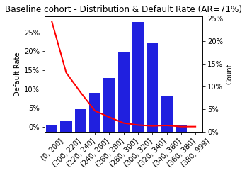

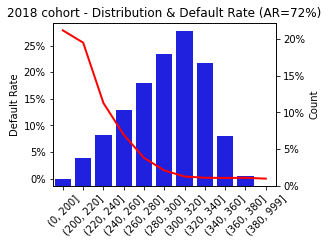

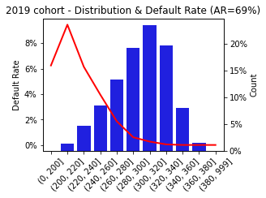

### Sub-segment Level Performance

The risk ranking tests were conducted on sub-segments. The results are shown in table below.

Risk Ranking Outcome

|  |  | Risk Ranking (AR) Baseline | Risk Ranking (AR) 2018 | Risk Ranking (AR) 2019 | # of Default Baseline | # of Default 2018 | # of Default 2019 | Outcome Baseline | Outcome 2018 | Outcome 2019 |
| --- | --- | --- | --- | --- | --- | --- | --- | --- | --- | --- |
| Product Type | CC | 69.6% | 75.0% | 73.1% | 294 | 450 | 72 | GREEN | GREEN | GREEN |
|  | OD | 71.6% | 65.1% | 49.0% | 239 | 367 | 96 | GREEN | GREEN | YELLOW |
|  | CC_OD | 66.5% | 60.2% | 54.1% | 73 | 1,033 | 98 | GREEN | GREEN | GREEN |
|  | With CC | 69.7% | 73.1% | 72.2% | 335 | 1,483 | 170 | GREEN | GREEN | GREEN |
|  | With OD | 72.6% | 62.4% | 51.7% | 271 | 1,400 | 194 | GREEN | GREEN | YELLOW |
| Gender | Male | 71.4% | 68.5% | 65.8% | 455 | 1,370 | 187 | GREEN | GREEN | GREEN |
|  | Female | 65.7% | 73.8% | 71.7% | 151 | 480 | 79 | GREEN | GREEN | GREEN |

*Place holder for user comments*  
e.g. Most of the sub segments remained strong in terms of risk ranking power, except for customers with OD (including customers with only OD). This is due to the agressive growth pre-2019, where the bank decided to tab on customers with lower income.

### Factor Level Performance

```python
sAROutcome, multiFactorARs = calcMultiFactorAR(dfBackend)
```

Factors Risk Ranking Performance

| cohort | Risk Ranking (AR) Baseline | Risk Ranking (AR) 2018 | Risk Ranking (AR) 2019 | Test Outcome Baseline | Test Outcome 2018 | Test Outcome 2019 |
| --- | --- | --- | --- | --- | --- | --- |
| Address Type | 2.5% | 1.9% | 2.8% | RED | YELLOW | YELLOW |
| Gender | 15.3% | 16.6% | 16.6% | GREEN | GREEN | GREEN |
| Education Level | 23.4% | 30.3% | 25.2% | GREEN | GREEN | GREEN |
| Residential Status | 13.3% | 14.3% | 23.1% | YELLOW | GREEN | GREEN |
| Years of Service | 16.9% | 9.4% | 5.9% | GREEN | YELLOW | YELLOW |
| Deposits L3M | 33.5% | 24.5% | 26.8% | GREEN | GREEN | GREEN |
| MOB From Credit Bureau | 28.2% | 35.3% | 31.6% | GREEN | GREEN | GREEN |
| Number of New Application's Enquiries in CB in L6M | 39.7% | 40.6% | 27.6% | GREEN | GREEN | GREEN |
| Ever 30+dpd in CB in L12M | 13.4% | 10.1% | 8.1% | YELLOW | GREEN | YELLOW |
| Months with Cash Advance L3M | 46.0% | 41.2% | 42.7% | GREEN | GREEN | GREEN |
| Partial Payment L3M | 48.3% | 41.8% | 45.2% | GREEN | GREEN | GREEN |

Address Type Factor - Distribution & Bad Rate

| Bucket | Score | Count Dev Baseline | Count Review 2018 | Count Review 2019 | Default Dev Baseline | Default Review 2018 | Default Review 2019 | Distribution Dev Baseline | Distribution Review 2018 | Distribution Review 2019 | Default Rate Dev Baseline | Default Rate Review 2018 | Default Rate Review 2019 |
| --- | --- | --- | --- | --- | --- | --- | --- | --- | --- | --- | --- | --- | --- |
| 01. Home | 27 | 26,620 | 45,103 | 22,071 | 572 | 1,779 | 255 | 96.8% | 98.0% | 98.7% | 2.15% | 3.94% | 1.16% |
| 02. Others | 10 | 883 | 937 | 299 | 34 | 71 | 11 | 3.2% | 2.0% | 1.3% | 3.85% | 7.58% | 3.68% |
| Total |  | 27,503 | 46,040 | 22,370 | 606 | 1,850 | 266 | 100.0% | 100.0% | 100.0% | 2.20% | 4.02% | 1.19% |

Years of Service Factor - Distribution & Bad Rate

| Bucket | Score | Count Dev Baseline | Count Review 2018 | Count Review 2019 | Default Dev Baseline | Default Review 2018 | Default Review 2019 | Distribution Dev Baseline | Distribution Review 2018 | Distribution Review 2019 | Default Rate Dev Baseline | Default Rate Review 2018 | Default Rate Review 2019 |
| --- | --- | --- | --- | --- | --- | --- | --- | --- | --- | --- | --- | --- | --- |
| 01. 1 year | 21 | 3,440 | 10,674 | 4,313 | 94 | 470 | 52 | 12.5% | 23.5% | 19.6% | 2.73% | 4.40% | 1.21% |
| 02. 2-6 years | 18 | 11,661 | 18,870 | 9,707 | 328 | 870 | 131 | 42.4% | 41.6% | 44.2% | 2.81% | 4.61% | 1.35% |
| 03. 7-9 years | 28 | 3,367 | 5,145 | 2,462 | 72 | 192 | 24 | 12.2% | 11.3% | 11.2% | 2.14% | 3.73% | 0.97% |
| 04. Above 9 years | 40 | 9,035 | 10,710 | 5,503 | 112 | 303 | 59 | 32.9% | 23.6% | 25.0% | 1.24% | 2.83% | 1.07% |
| Total |  | 27,503 | 45,399 | 21,985 | 606 | 1,835 | 266 | 100.0% | 100.0% | 100.0% | 2.20% | 4.04% | 1.21% |

Ever 30+dpd in CB in L12M Factor - Distribution & Bad Rate

| Bucket | Score | Count Dev Baseline | Count Review 2018 | Count Review 2019 | Default Dev Baseline | Default Review 2018 | Default Review 2019 | Distribution Dev Baseline | Distribution Review 2018 | Distribution Review 2019 | Default Rate Dev Baseline | Default Rate Review 2018 | Default Rate Review 2019 |
| --- | --- | --- | --- | --- | --- | --- | --- | --- | --- | --- | --- | --- | --- |
| 01. Yes | 6 | 2,258 | 6,214 | 2,240 | 129 | 429 | 48 | 8.2% | 13.5% | 10.0% | 5.71% | 6.90% | 2.14% |
| 02. No | 28 | 25,245 | 39,826 | 20,130 | 477 | 1,421 | 218 | 91.8% | 86.5% | 90.0% | 1.89% | 3.57% | 1.08% |
| Total |  | 27,503 | 46,040 | 22,370 | 606 | 1,850 | 266 | 100.0% | 100.0% | 100.0% | 2.20% | 4.02% | 1.19% |

# Appendices

## Factor Distribution

Each of 11 factors distribution and bad rate are shown in this section.

Address Type Factor - Distribution & Bad Rate

| Bucket | Score | Count Dev Baseline | Count Review 2018 | Count Review 2019 | Default Dev Baseline | Default Review 2018 | Default Review 2019 | Distribution Dev Baseline | Distribution Review 2018 | Distribution Review 2019 | Default Rate Dev Baseline | Default Rate Review 2018 | Default Rate Review 2019 |
| --- | --- | --- | --- | --- | --- | --- | --- | --- | --- | --- | --- | --- | --- |
| 01. Home | 27 | 26,620 | 45,103 | 22,071 | 572 | 1,779 | 255 | 96.8% | 98.0% | 98.7% | 2.15% | 3.94% | 1.16% |
| 02. Others | 10 | 883 | 937 | 299 | 34 | 71 | 11 | 3.2% | 2.0% | 1.3% | 3.85% | 7.58% | 3.68% |
| Total |  | 27,503 | 46,040 | 22,370 | 606 | 1,850 | 266 | 100.0% | 100.0% | 100.0% | 2.20% | 4.02% | 1.19% |

Gender Factor - Distribution & Bad Rate

| Bucket | Score | Count Dev Baseline | Count Review 2018 | Count Review 2019 | Default Dev Baseline | Default Review 2018 | Default Review 2019 | Distribution Dev Baseline | Distribution Review 2018 | Distribution Review 2019 | Default Rate Dev Baseline | Default Rate Review 2018 | Default Rate Review 2019 |
| --- | --- | --- | --- | --- | --- | --- | --- | --- | --- | --- | --- | --- | --- |
| 01. Male | 6 | 16,524 | 26,771 | 12,055 | 455 | 1,370 | 187 | 60.1% | 58.1% | 53.9% | 2.75% | 5.12% | 1.55% |
| 02. Female | 25 | 10,979 | 19,269 | 10,315 | 151 | 480 | 79 | 39.9% | 41.9% | 46.1% | 1.38% | 2.49% | 0.77% |
| Total |  | 27,503 | 46,040 | 22,370 | 606 | 1,850 | 266 | 100.0% | 100.0% | 100.0% | 2.20% | 4.02% | 1.19% |

Education Level Factor - Distribution & Bad Rate

| Bucket | Score | Count Dev Baseline | Count Review 2018 | Count Review 2019 | Default Dev Baseline | Default Review 2018 | Default Review 2019 | Distribution Dev Baseline | Distribution Review 2018 | Distribution Review 2019 | Default Rate Dev Baseline | Default Rate Review 2018 | Default Rate Review 2019 |
| --- | --- | --- | --- | --- | --- | --- | --- | --- | --- | --- | --- | --- | --- |
| 01. Degree & Above | 38 | 10,961 | 21,403 | 10,310 | 149 | 388 | 58 | 39.9% | 46.5% | 46.1% | 1.36% | 1.81% | 0.56% |
| 02. Pre-Uni | 36 | 1,605 | 1,575 | 684 | 24 | 66 | 14 | 5.8% | 3.4% | 3.1% | 1.50% | 4.19% | 2.05% |
| 03. Diploma & Cert | 29 | 7,727 | 13,477 | 6,530 | 161 | 712 | 106 | 28.1% | 29.3% | 29.2% | 2.08% | 5.28% | 1.62% |
| 04. Others | 7 | 7,210 | 9,585 | 4,846 | 272 | 684 | 88 | 26.2% | 20.8% | 21.7% | 3.77% | 7.14% | 1.82% |
| Total |  | 27,503 | 46,040 | 22,370 | 606 | 1,850 | 266 | 100.0% | 100.0% | 100.0% | 2.20% | 4.02% | 1.19% |

Residential Status Factor - Distribution & Bad Rate

| Bucket | Score | Count Dev Baseline | Count Review 2018 | Count Review 2019 | Default Dev Baseline | Default Review 2018 | Default Review 2019 | Distribution Dev Baseline | Distribution Review 2018 | Distribution Review 2019 | Default Rate Dev Baseline | Default Rate Review 2018 | Default Rate Review 2019 |
| --- | --- | --- | --- | --- | --- | --- | --- | --- | --- | --- | --- | --- | --- |
| 01. Own | 32 | 7,056 | 19,476 | 7,672 | 107 | 626 | 58 | 25.7% | 42.3% | 34.3% | 1.52% | 3.21% | 0.76% |
| 02. Mortgage | 27 | 13,756 | 9,243 | 5,009 | 301 | 273 | 40 | 50.0% | 20.1% | 22.4% | 2.19% | 2.95% | 0.80% |
| 03. Parent | 21 | 4,885 | 10,567 | 5,403 | 125 | 554 | 77 | 17.8% | 23.0% | 24.2% | 2.56% | 5.24% | 1.43% |
| 04. Others | 13 | 1,806 | 6,754 | 4,286 | 73 | 397 | 91 | 6.6% | 14.7% | 19.2% | 4.04% | 5.88% | 2.12% |
| Total |  | 27,503 | 46,040 | 22,370 | 606 | 1,850 | 266 | 100.0% | 100.0% | 100.0% | 2.20% | 4.02% | 1.19% |

Years of Service Factor - Distribution & Bad Rate

| Bucket | Score | Count Dev Baseline | Count Review 2018 | Count Review 2019 | Default Dev Baseline | Default Review 2018 | Default Review 2019 | Distribution Dev Baseline | Distribution Review 2018 | Distribution Review 2019 | Default Rate Dev Baseline | Default Rate Review 2018 | Default Rate Review 2019 |
| --- | --- | --- | --- | --- | --- | --- | --- | --- | --- | --- | --- | --- | --- |
| 01. 1 year | 21 | 3,440 | 10,674 | 4,313 | 94 | 470 | 52 | 12.5% | 23.5% | 19.6% | 2.73% | 4.40% | 1.21% |
| 02. 2-6 years | 18 | 11,661 | 18,870 | 9,707 | 328 | 870 | 131 | 42.4% | 41.6% | 44.2% | 2.81% | 4.61% | 1.35% |
| 03. 7-9 years | 28 | 3,367 | 5,145 | 2,462 | 72 | 192 | 24 | 12.2% | 11.3% | 11.2% | 2.14% | 3.73% | 0.97% |
| 04. Above 9 years | 40 | 9,035 | 10,710 | 5,503 | 112 | 303 | 59 | 32.9% | 23.6% | 25.0% | 1.24% | 2.83% | 1.07% |
| Total |  | 27,503 | 45,399 | 21,985 | 606 | 1,835 | 266 | 100.0% | 100.0% | 100.0% | 2.20% | 4.04% | 1.21% |

Deposits L3M Factor - Distribution & Bad Rate

| Bucket | Score | Count Dev Baseline | Count Review 2018 | Count Review 2019 | Default Dev Baseline | Default Review 2018 | Default Review 2019 | Distribution Dev Baseline | Distribution Review 2018 | Distribution Review 2019 | Default Rate Dev Baseline | Default Rate Review 2018 | Default Rate Review 2019 |
| --- | --- | --- | --- | --- | --- | --- | --- | --- | --- | --- | --- | --- | --- |
| 01. No deposits | 26 | 14,925 | 27,504 | 12,467 | 373 | 1,531 | 219 | 54.3% | 59.7% | 55.7% | 2.50% | 5.57% | 1.76% |
| 02. < \$500 | 1 | 2,318 | 2,309 | 1,114 | 148 | 101 | 12 | 8.4% | 5.0% | 5.0% | 6.38% | 4.37% | 1.08% |
| 03. [\$500,\$10k) | 34 | 5,465 | 9,798 | 5,228 | 68 | 182 | 34 | 19.9% | 21.3% | 23.4% | 1.24% | 1.86% | 0.65% |
| 04. $10k & Above | 39 | 4,795 | 6,428 | 3,558 | 17 | 36 | 1 | 17.4% | 14.0% | 15.9% | 0.35% | 0.56% | 0.03% |
| Total |  | 27,503 | 46,039 | 22,367 | 606 | 1,850 | 266 | 100.0% | 100.0% | 100.0% | 2.20% | 4.02% | 1.19% |

MOB From Credit Bureau Factor - Distribution & Bad Rate

| Bucket | Score | Count Dev Baseline | Count Review 2018 | Count Review 2019 | Default Dev Baseline | Default Review 2018 | Default Review 2019 | Distribution Dev Baseline | Distribution Review 2018 | Distribution Review 2019 | Default Rate Dev Baseline | Default Rate Review 2018 | Default Rate Review 2019 |
| --- | --- | --- | --- | --- | --- | --- | --- | --- | --- | --- | --- | --- | --- |
| 01. <= 1 year | 10 | 4,063 | 10,668 | 3,849 | 189 | 882 | 97 | 14.8% | 23.2% | 17.2% | 4.65% | 8.27% | 2.52% |
| 02. 2-3 years | 25 | 7,973 | 10,985 | 6,455 | 203 | 497 | 97 | 29.0% | 23.9% | 28.9% | 2.55% | 4.52% | 1.50% |
| 03. 4-9 years | 30 | 10,220 | 16,914 | 8,492 | 169 | 369 | 51 | 37.2% | 36.7% | 38.0% | 1.65% | 2.18% | 0.60% |
| 04. >= 10 years | 36 | 5,247 | 7,473 | 3,574 | 45 | 102 | 21 | 19.1% | 16.2% | 16.0% | 0.86% | 1.36% | 0.59% |
| Total |  | 27,503 | 46,040 | 22,370 | 606 | 1,850 | 266 | 100.0% | 100.0% | 100.0% | 2.20% | 4.02% | 1.19% |

Number of New Application's Enquiries in CB in L6M Factor - Distribution & Bad Rate

| Bucket | Score | Count Dev Baseline | Count Review 2018 | Count Review 2019 | Default Dev Baseline | Default Review 2018 | Default Review 2019 | Distribution Dev Baseline | Distribution Review 2018 | Distribution Review 2019 | Default Rate Dev Baseline | Default Rate Review 2018 | Default Rate Review 2019 |
| --- | --- | --- | --- | --- | --- | --- | --- | --- | --- | --- | --- | --- | --- |
| 05. No CB | 42 | 5,256 | 679 | 482 | 38 | 8 | 5 | 19.1% | 1.5% | 2.2% | 0.72% | 1.18% | 1.04% |
| 01. No enquiry | 41 | 7,828 | 15,397 | 9,740 | 92 | 223 | 58 | 28.5% | 33.4% | 43.5% | 1.18% | 1.45% | 0.60% |
| 02. 1-2 | 37 | 10,748 | 18,932 | 9,146 | 234 | 621 | 125 | 39.1% | 41.1% | 40.9% | 2.18% | 3.28% | 1.37% |
| 03. 3-4 | 28 | 2,564 | 7,077 | 2,936 | 119 | 460 | 78 | 9.3% | 15.4% | 13.1% | 4.64% | 6.50% | 2.66% |
| 04. >= 5 | 1 | 1,107 | 3,955 | 66 | 123 | 538 | 0 | 4.0% | 8.6% | 0.3% | 11.11% | 13.60% | 0.00% |
| Total |  | 27,503 | 46,040 | 22,370 | 606 | 1,850 | 266 | 100.0% | 100.0% | 100.0% | 2.20% | 4.02% | 1.19% |

Ever 30+dpd in CB in L12M Factor - Distribution & Bad Rate

| Bucket | Score | Count Dev Baseline | Count Review 2018 | Count Review 2019 | Default Dev Baseline | Default Review 2018 | Default Review 2019 | Distribution Dev Baseline | Distribution Review 2018 | Distribution Review 2019 | Default Rate Dev Baseline | Default Rate Review 2018 | Default Rate Review 2019 |
| --- | --- | --- | --- | --- | --- | --- | --- | --- | --- | --- | --- | --- | --- |
| 01. Yes | 6 | 2,258 | 6,214 | 2,240 | 129 | 429 | 48 | 8.2% | 13.5% | 10.0% | 5.71% | 6.90% | 2.14% |
| 02. No | 28 | 25,245 | 39,826 | 20,130 | 477 | 1,421 | 218 | 91.8% | 86.5% | 90.0% | 1.89% | 3.57% | 1.08% |
| Total |  | 27,503 | 46,040 | 22,370 | 606 | 1,850 | 266 | 100.0% | 100.0% | 100.0% | 2.20% | 4.02% | 1.19% |

Months with Cash Advance L3M Factor - Distribution & Bad Rate

| Bucket | Score | Count Dev Baseline | Count Review 2018 | Count Review 2019 | Default Dev Baseline | Default Review 2018 | Default Review 2019 | Distribution Dev Baseline | Distribution Review 2018 | Distribution Review 2019 | Default Rate Dev Baseline | Default Rate Review 2018 | Default Rate Review 2019 |
| --- | --- | --- | --- | --- | --- | --- | --- | --- | --- | --- | --- | --- | --- |
| 01. 0 | 35 | 22,367 | 36,105 | 18,512 | 232 | 745 | 111 | 81.3% | 78.4% | 82.8% | 1.04% | 2.06% | 0.60% |
| 02. 1-2 | 15 | 1,332 | 2,822 | 1,043 | 93 | 393 | 51 | 4.8% | 6.1% | 4.7% | 6.98% | 13.93% | 4.89% |
| 03. 3 | 1 | 1,752 | 4,249 | 1,581 | 180 | 532 | 74 | 6.4% | 9.2% | 7.1% | 10.27% | 12.52% | 4.68% |
| 04. N.A | 17 | 2,052 | 2,864 | 1,234 | 101 | 180 | 30 | 7.5% | 6.2% | 5.5% | 4.92% | 6.28% | 2.43% |
| Total |  | 27,503 | 46,040 | 22,370 | 606 | 1,850 | 266 | 100.0% | 100.0% | 100.0% | 2.20% | 4.02% | 1.19% |

Partial Payment L3M Factor - Distribution & Bad Rate

| Bucket | Score | Count Dev Baseline | Count Review 2018 | Count Review 2019 | Default Dev Baseline | Default Review 2018 | Default Review 2019 | Distribution Dev Baseline | Distribution Review 2018 | Distribution Review 2019 | Default Rate Dev Baseline | Default Rate Review 2018 | Default Rate Review 2019 |
| --- | --- | --- | --- | --- | --- | --- | --- | --- | --- | --- | --- | --- | --- |
| 01. 0 | 39 | 9,287 | 22,429 | 11,845 | 51 | 330 | 54 | 33.8% | 48.7% | 53.0% | 0.55% | 1.47% | 0.46% |
| 02. 1 | 38 | 6,101 | 6,503 | 2,998 | 39 | 201 | 13 | 22.2% | 14.1% | 13.4% | 0.64% | 3.09% | 0.43% |
| 03. 2 | 31 | 3,393 | 3,882 | 1,649 | 68 | 191 | 21 | 12.3% | 8.4% | 7.4% | 2.00% | 4.92% | 1.27% |
| 04. 3 | 9 | 6,561 | 10,359 | 4,642 | 342 | 948 | 148 | 23.9% | 22.5% | 20.8% | 5.21% | 9.15% | 3.19% |
| 05. N.A | 10 | 2,161 | 2,867 | 1,236 | 106 | 180 | 30 | 7.9% | 6.2% | 5.5% | 4.91% | 6.28% | 2.43% |
| Total |  | 27,503 | 46,040 | 22,370 | 606 | 1,850 | 266 | 100.0% | 100.0% | 100.0% | 2.20% | 4.02% | 1.19% |

## Chronology

[output not shown]

---- End of Document ----

Thank you.